# Authorship Poll Analysis

Meghan Duffy

June 15, 2016

# What are the current views on last and corresponding authorship in ecology?

### Analysis of data from Dynamic Ecology poll regarding authorship practices in ecology

## Introduction

Who is the last author on a paper? Is it the person who did the least work? Or is it the PI of the lab where the work was done? When I started grad school (in 2000), the norm in ecology was still that the last author on a paper is the person who did the least work. But, more recently, it has seemed to me that the norm is that the last author on a paper is the “senior” author (usually the PI). However, if you talk with other ecologists about the topic, it’s clear that there’s variation in views, and that not everyone is on the same page.

Thinking about this topic as we were settling on authorship order for a manuscript recently led me to post [a series of tweets where I mused about authorship practices in ecology](https://twitter.com/duffy_ma/status/710917668446928896) which then led me to do [a poll on Dynamic Ecology related to the topic](https://dynamicecology.wordpress.com/2016/04/06/poll-what-are-your-views-on-last-and-corresponding-authorship-in-ecology/). The poll was developed with input from Alex Bond, Linda Campbell, Kathy Cottingham, and Andrea Kirkwood, who all helped me think through what to ask about and how to phrase the questions and answer options. Many thanks to them for their help! And, while I’m doing acknowledgments, Auriel Fournier, Jaime Ashander, and Rayna Harris provided R help that got me over some key hurdles. Finally, this poll was confirmed as exempt from ongoing IRB review (UMich IRB #: HUM00114140).

## The poll

The poll had four main questions:

1. For ecology papers, do you consider the last author to be the senior author?
2. Which of the following statements most closely matches the current norms in ecology in terms of who is corresponding author?
3. Which of the following statements would be best practice in terms of who is corresponding author?
4. If someone includes a statement on his/her CV indicating they have used a first/last author emphasis, do you pay attention to that?

It also asked about the respondent’s primary research area, whether their research is primarily basic or applied, how frequently they conduct interdisciplinary research, how many years post-PhD they are, where they live, and what their current department is.

The poll first appeared on 6 April 2016 and ran for two weeks.

## Data manipulation

Four blank entries were deleted. I am a bad person and used excel to add in numeric codes for the different answers. The key is:

For the question about whether last author is the senior author:

```
1 = No
2 = It depends, but probably no
3 = Not sure, but probably no
4 = Not sure, but probably yes
5 = It depends, but probably yes
6 = Yes
```

For the question about current corresponding author practices:

```
1 = The corresponding author is the person that has taken responsibility for fielding questions about the paper post-publication
2 = The corresponding author is the person with the most stable contact info and/or internet access
3 = The corresponding author is usually the person who uploaded the files (usually the first author)
4 = The corresponding author is usually the senior author
5 = The corresponding author uploaded the files, managed the revisions and wrote the response to reviewers, and took responsibility for the paper after publication
```

For the question about best corresponding author practices:

```
1 = The corresponding author should be the person that has taken responsibility for fielding questions about the paper post-publication
2 = The corresponding author should be the person with the most stable contact info and/or internet access
3 = The corresponding author should be whichever person uploaded the files (usually the first author)
4 = The corresponding author should be the senior author
5 = The corresponding author should be the person who uploaded the files, managed the revisions and wrote the response to reviewers, and took responsibility for the paper after publication
```

For the question about the CV statement:

```
1 = No
2 = I have never seen this, but would probably not pay attention to it
3 = I have never seen this, but would probably pay attention to it
4 = Yes
```

For the question about research area:

```
1 = Ecology (primarily field-based)
2 = Ecology (primarily wet-lab based, including molecular ecology)
3 = Ecology (primarily computational-based)
4 = Evolutionary biology (primarily molecular)
5 = Evolutionary biology (primarily organismal)
6 = Biology other than EEB
7 = Outside biology
```

For the basic vs. applied question:

```
1 = basic
2 = applied
```

For the interdisciplinarity question:

```
1 = Never
2 = Rarely
3 = Sometimes
4 = Often
5 = Always
```

Years since PhD

```
1 = 0 (current students and people without a PhD should choose this)
2 = 1-5
3 = 6-10
4 = 11-15
5 = 16-20
6 = >20
7 = I do not have a PhD and am not a current student
```

Where live?

```
1 = Africa
2 = Asia
3 = Australia
4 = Europe
5 = North America
6 = South America
```

Department:

```
1 = An EEB department (or similar)
2 = A biology department
3 = A natural resources department (or similar)
4 = other
```

## Basic overview of responses

After removing the four blank responses, there were 1122 responses to the poll. What did the respondents look like?

Primary Research Area of Respondents

| PrimaryResearch | n | rel.freq |
| --- | --- | --- |
| Biology other than EEB | 24 | 2 |
| Ecology (primarily computational-based) | 217 | 19 |
| Ecology (primarily field-based) | 558 | 50 |
| Ecology (primarily wet-lab based, including molecular ecology) | 119 | 11 |
| Evolutionary biology (primarily molecular) | 51 | 5 |
| Evolutionary biology (primarily organismal) | 130 | 12 |
| Outside biology | 21 | 2 |

| BasicApplied | n | rel.freq |
| --- | --- | --- |
| Applied | 362 | 33 |
| Basic | 751 | 67 |

| Interdisciplinary | n | rel.freq |
| --- | --- | --- |
| Always | 50 | 4 |
| Often | 271 | 24 |
| Sometimes | 401 | 36 |
| Rarely | 293 | 26 |
| Never | 99 | 9 |

[output not shown]

| WhereLive | n | rel.freq |
| --- | --- | --- |
| Africa | 8 | 1 |
| Asia | 13 | 1 |
| Australia | 63 | 6 |
| Europe | 288 | 26 |
| North America | 717 | 64 |
| South America | 30 | 3 |

| Dept01 | n | rel.freq |
| --- | --- | --- |
| 1 | 304 | 28 |
| 2 | 444 | 41 |
| 3 | 212 | 19 |
| 4 | 134 | 12 |

## Results for the four main questions

### Q1: “For ecology papers, do you consider the last author to be the senior author?”

```
## # A tibble: 6 x 3
##   LastSenior01     n rel.freq
##          <int> <int>    <dbl>
## 1            1    77        7
## 2            2    61        5
## 3            3    19        2
## 4            4    88        8
## 5            5   395       35
## 6            6   480       43
```

```
## [1] 1 2 3 4 5 6
## Levels: 1 2 3 4 5 6
```

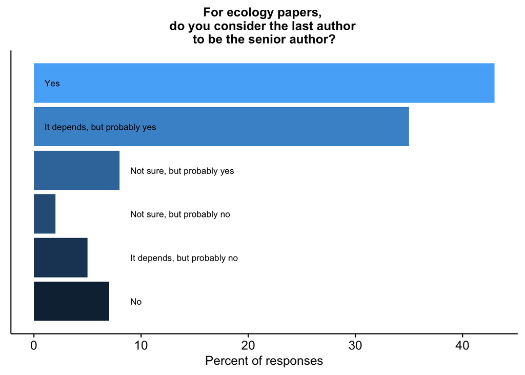

### Q2: “Which of the following statements most closely matches the current norms in ecology in terms of who is corresponding author?”

```
## # A tibble: 5 x 3
##   CorrespondingCurrent01     n rel.freq
##                    <int> <int>    <dbl>
## 1                      1   182       16
## 2                      2    37        3
## 3                      3   215       19
## 4                      4    82        7
## 5                      5   602       54
```

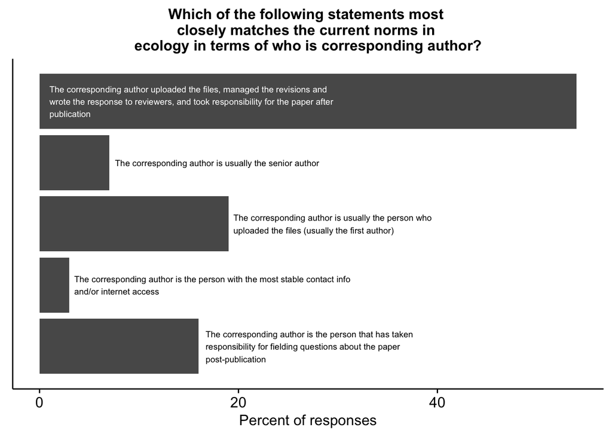

### Q3: “Which of the following statements would be best practice in terms of who is corresponding author?”

```
## # A tibble: 5 x 3
##   CorrespondingBest01     n rel.freq
##                 <int> <int>    <dbl>
## 1                   1   266       24
## 2                   2    40        4
## 3                   3    84        8
## 4                   4    46        4
## 5                   5   676       61
```

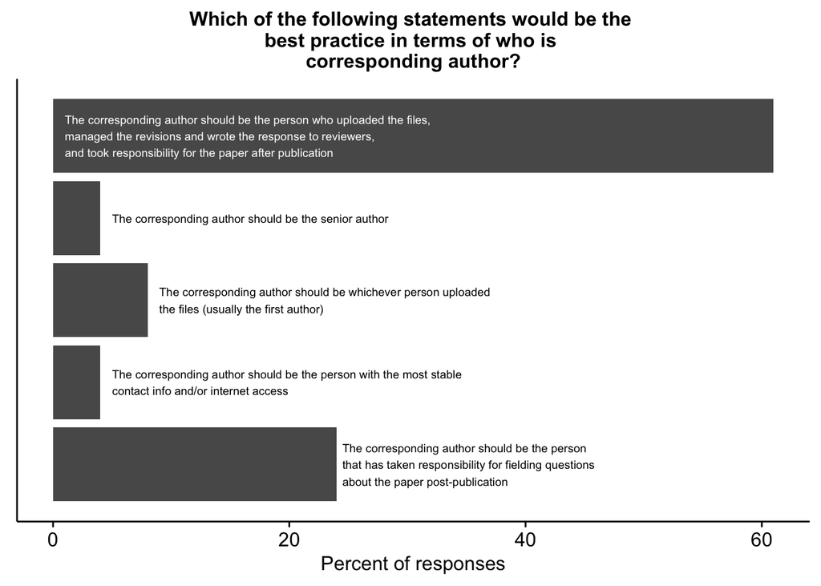

### Q4: “If someone includes a statement on his/her CV indicating they have used a first/last author emphasis, do you pay attention to that?”

```
## # A tibble: 4 x 3
##   CVStatement01     n rel.freq
##           <int> <int>    <dbl>
## 1             1    87        8
## 2             2   234       21
## 3             3   538       49
## 4             4   245       22
```

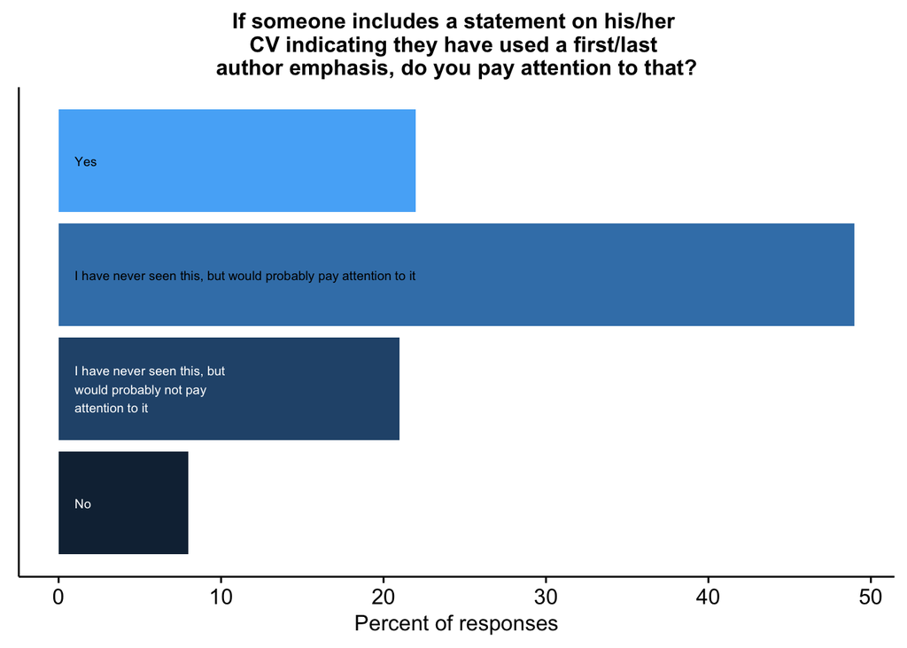

## Looking at cross-tabs

### Does whether people view the last author as the senior author vary based on age, country, research area, and/or department?

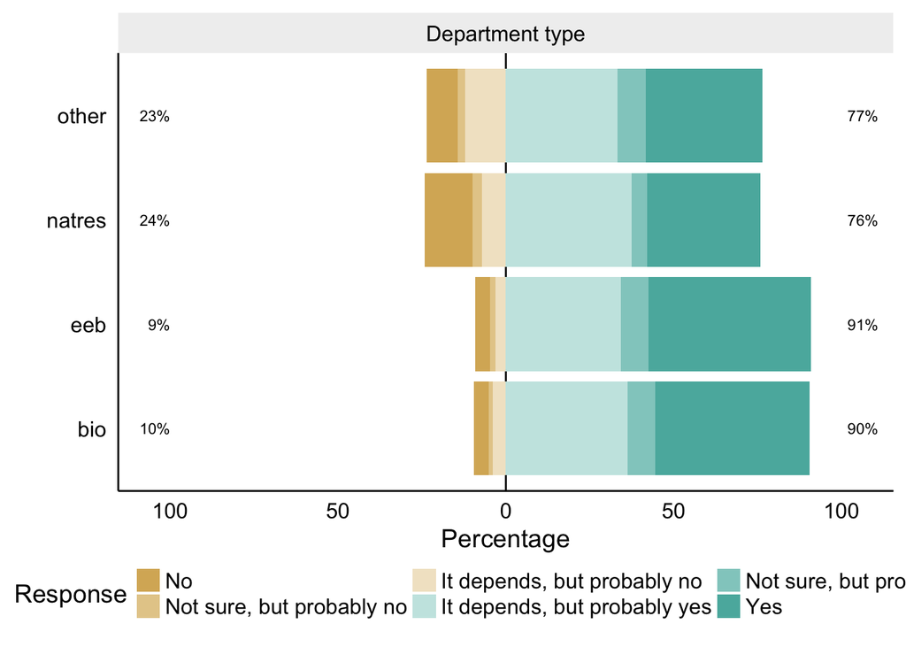

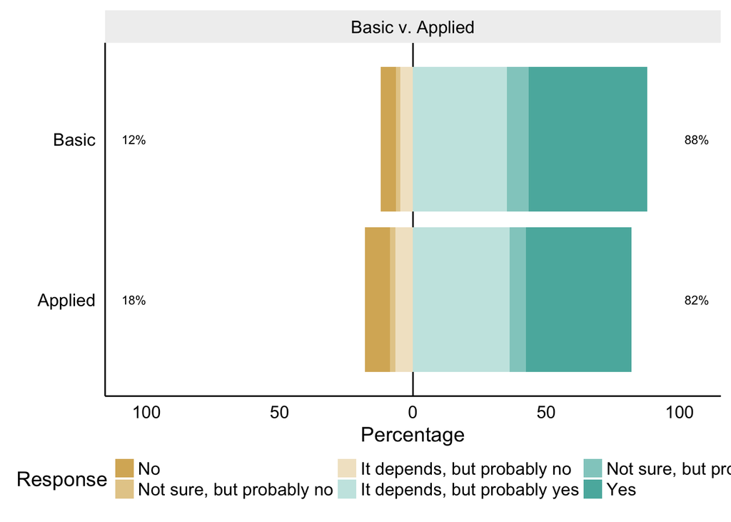

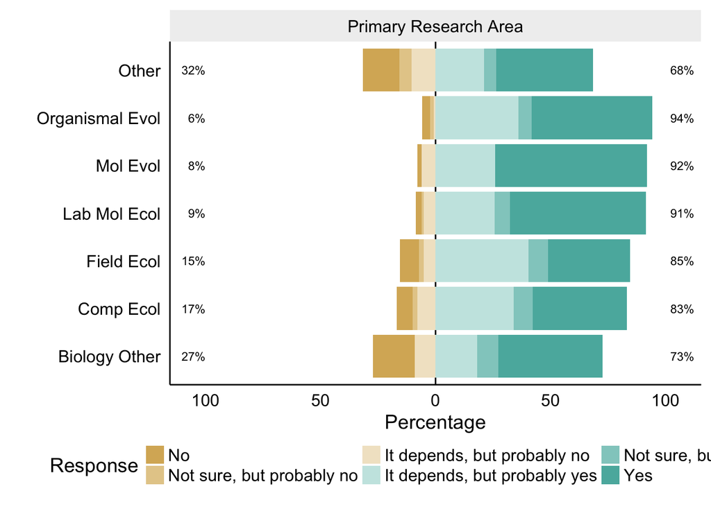

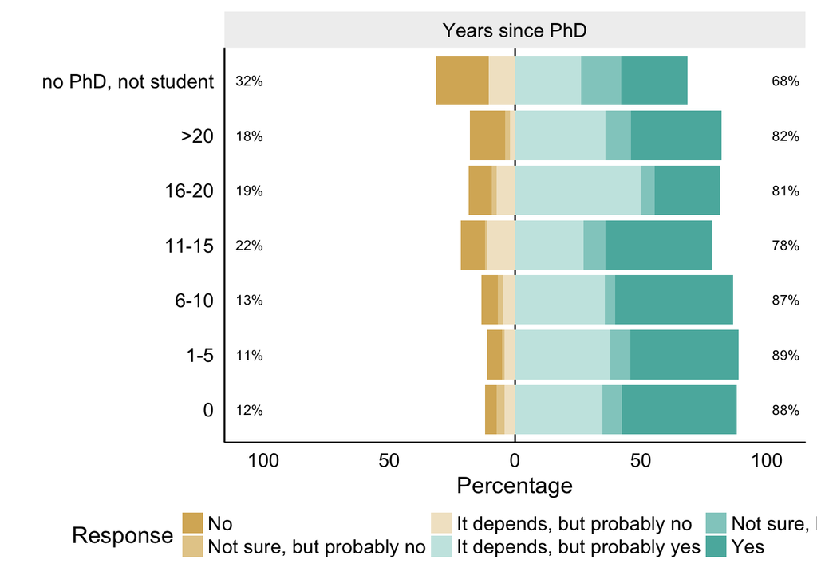

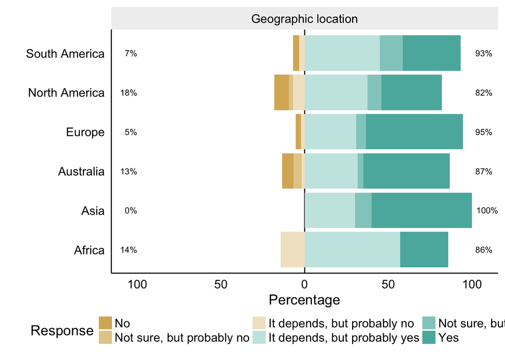

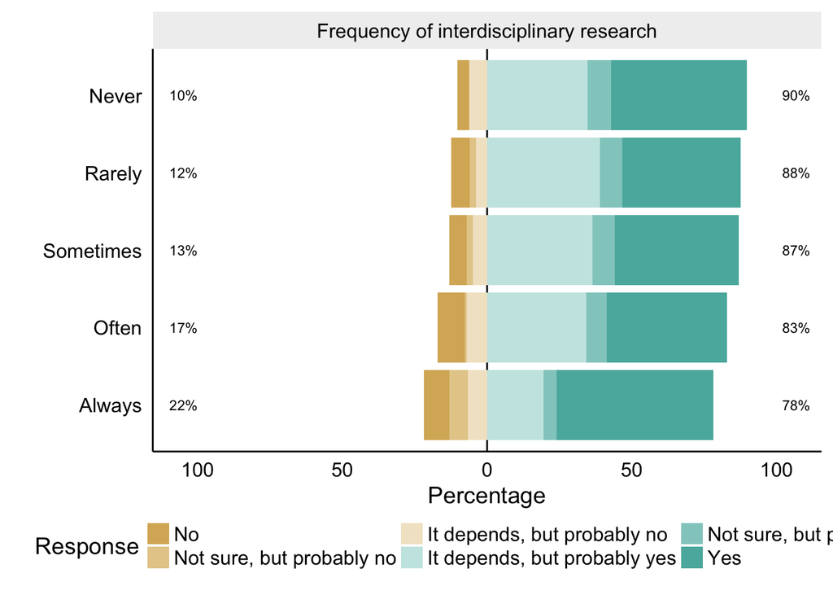

### Does whether people pay attention to a CV statement vary based on age, country, research area, department and/or their views on last authorship?

```
## [1] "Biology other than EEB"
## [2] "Ecology (primarily computational-based)"
## [3] "Ecology (primarily field-based)"
## [4] "Ecology (primarily wet-lab based, including molecular ecology)"
## [5] "Evolutionary biology (primarily molecular)"
## [6] "Evolutionary biology (primarily organismal)"
## [7] "Outside biology"
```

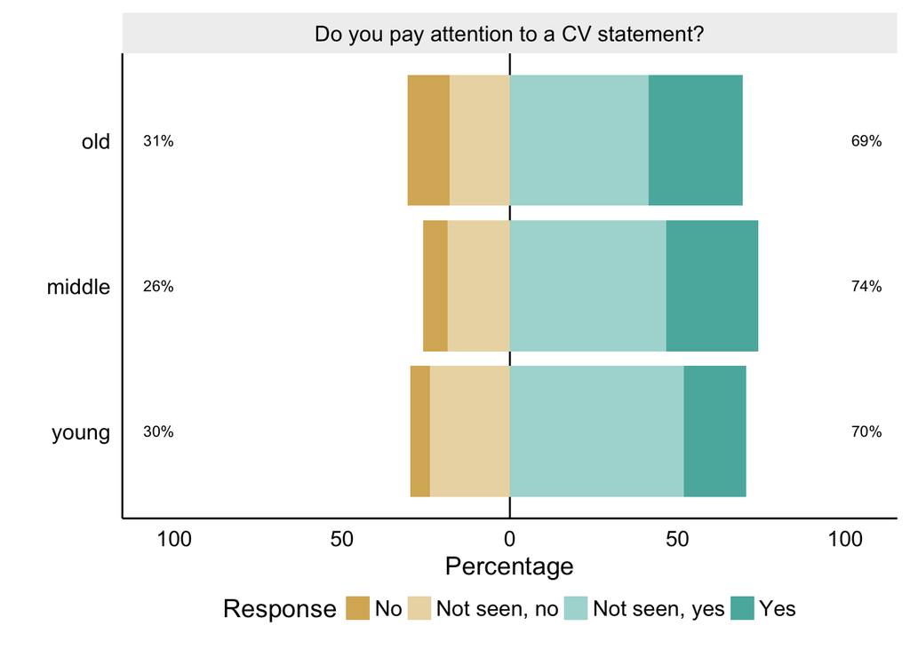

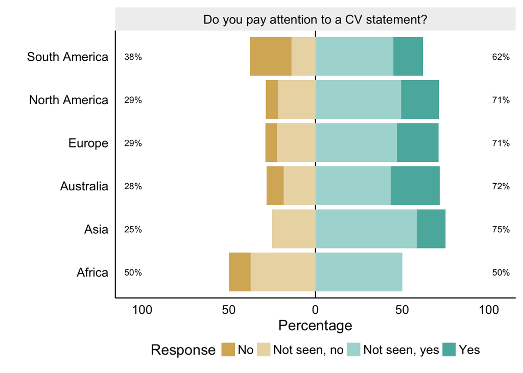

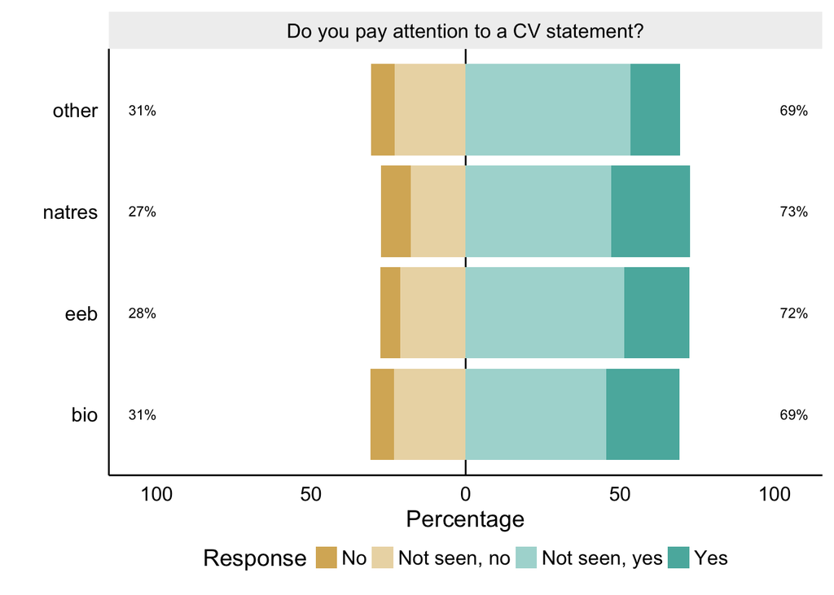

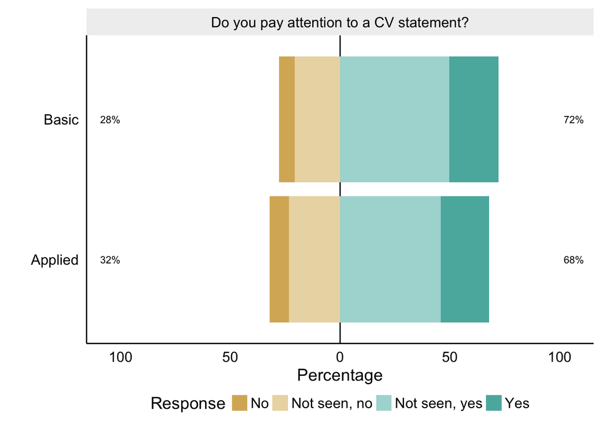

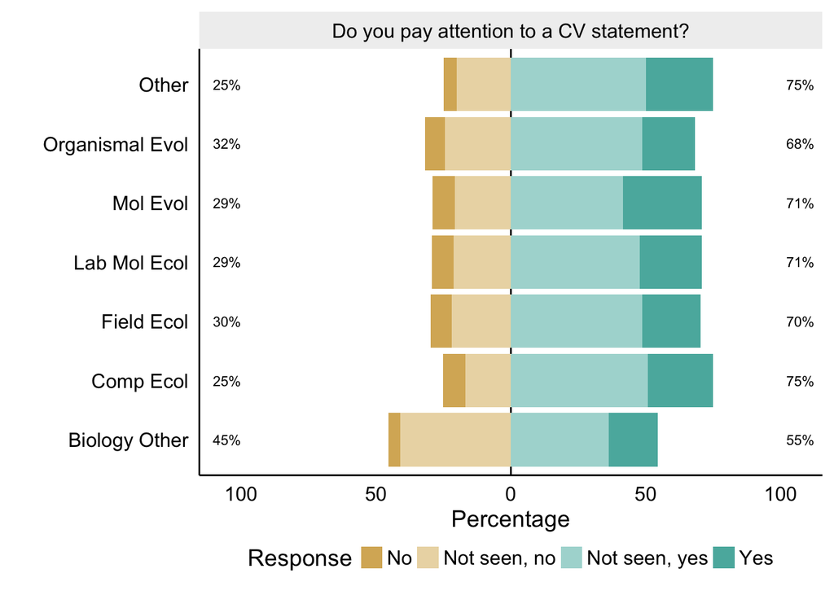

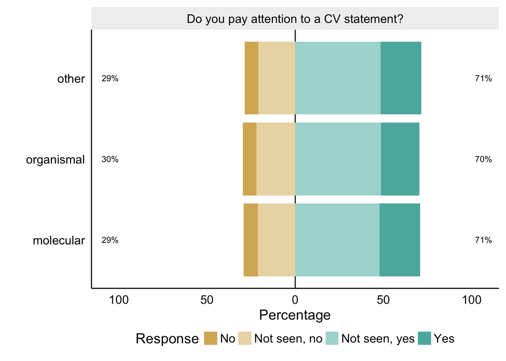

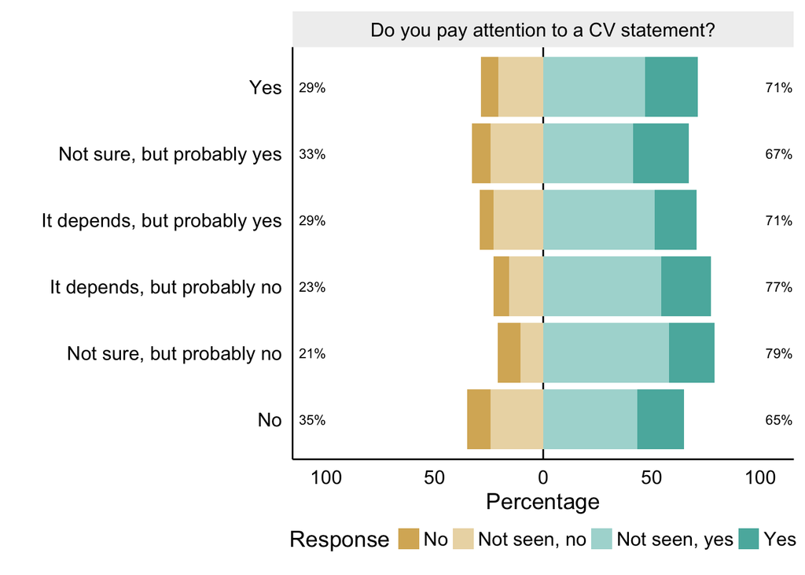

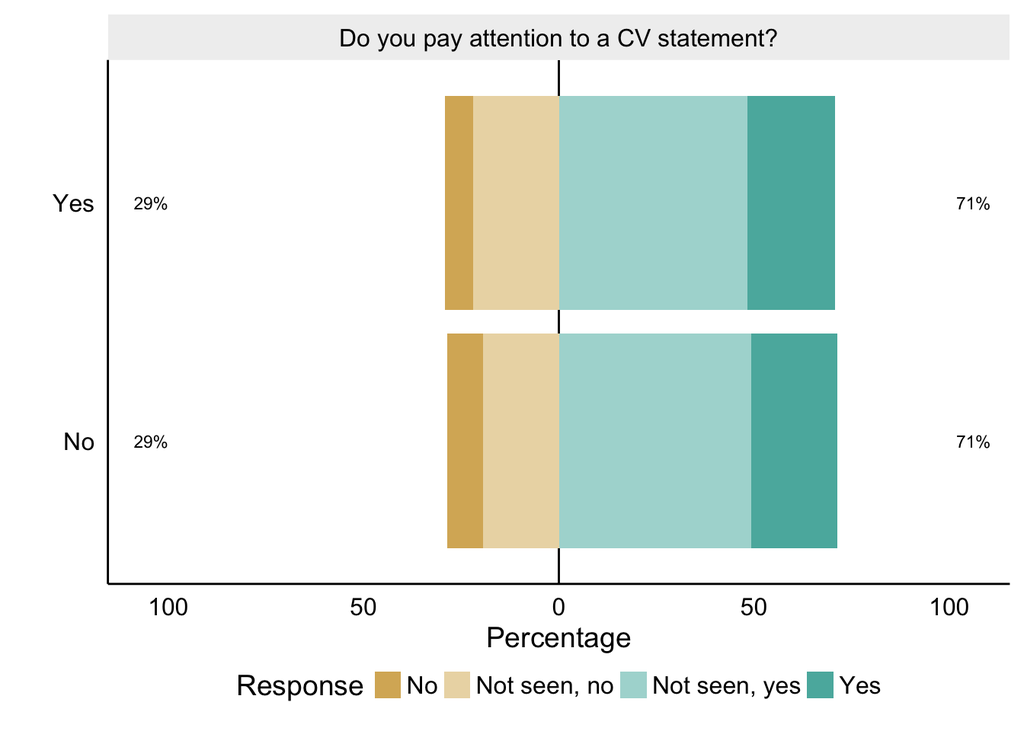

## Analysis of data on papers in Ecology 1956-2016

```
## 'data.frame':    382 obs. of  10 variables:
##  $ Journal       : Factor w/ 3 levels "AmNat","Ecology",..: 2 2 2 2 2 2 2 2 2 2 ...
##  $ Year          : int  1956 1956 1956 1956 1956 1956 1956 1956 1956 1956 ...
##  $ Volume        : int  1 1 1 1 1 1 1 1 1 1 ...
##  $ Article.type  : Factor w/ 9 levels "article","briefcomm",..: 1 1 1 1 1 1 1 1 1 1 ...
##  $ First.page    : Factor w/ 250 levels "1","100","103",..: 1 224 92 133 164 187 208 218 220 226 ...
##  $ Author.names  : Factor w/ 273 levels "","\xafkland & Bj\xbfrnstad",..: 215 93 33 171 246 119 182 27 74 221 ...
##  $ Number.authors: int  1 1 1 2 1 2 1 1 3 1 ...
##  $ Corresponding : Factor w/ 14 levels "","1","2","20",..: 13 13 13 13 13 13 13 13 13 13 ...
##  $ Notes         : Factor w/ 28 levels "","all three authors have email addresses",..: NA NA NA NA NA 15 NA NA 24 NA ...
##  $ Correspondence: Factor w/ 6 levels "all","first",..: 5 5 5 5 5 5 5 5 5 5 ...
```

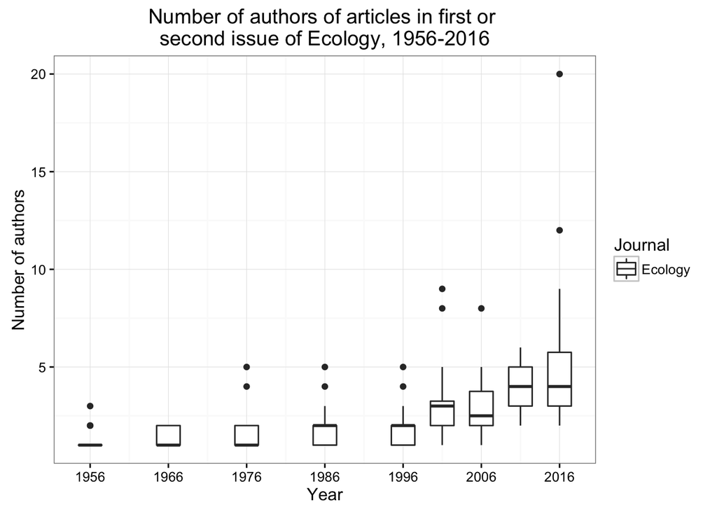

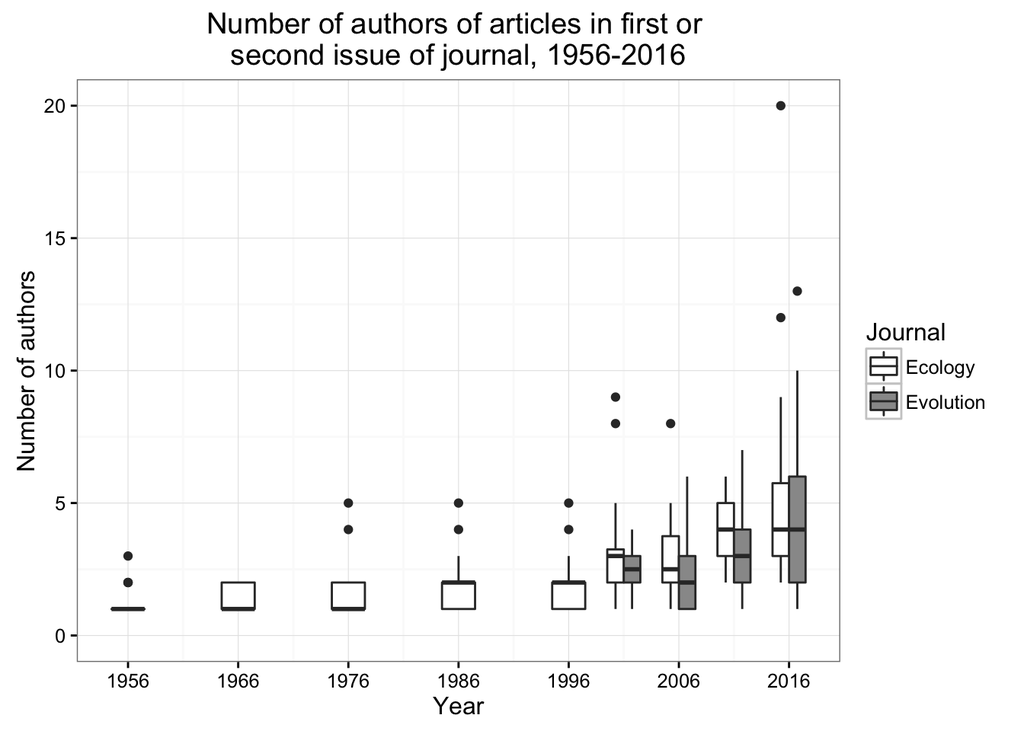

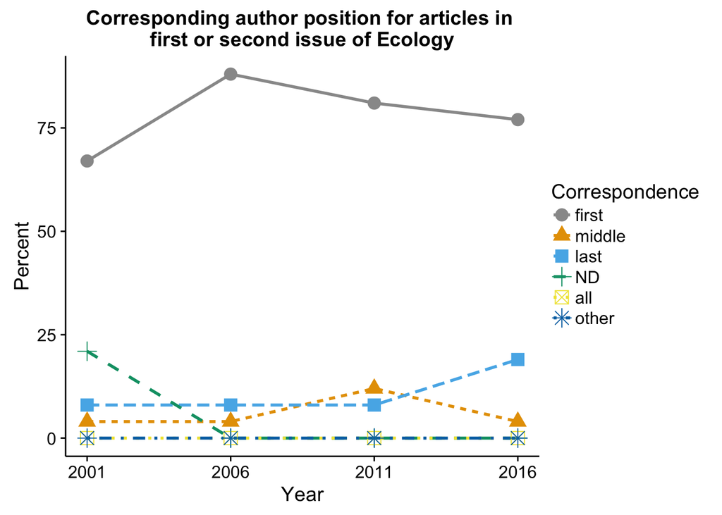

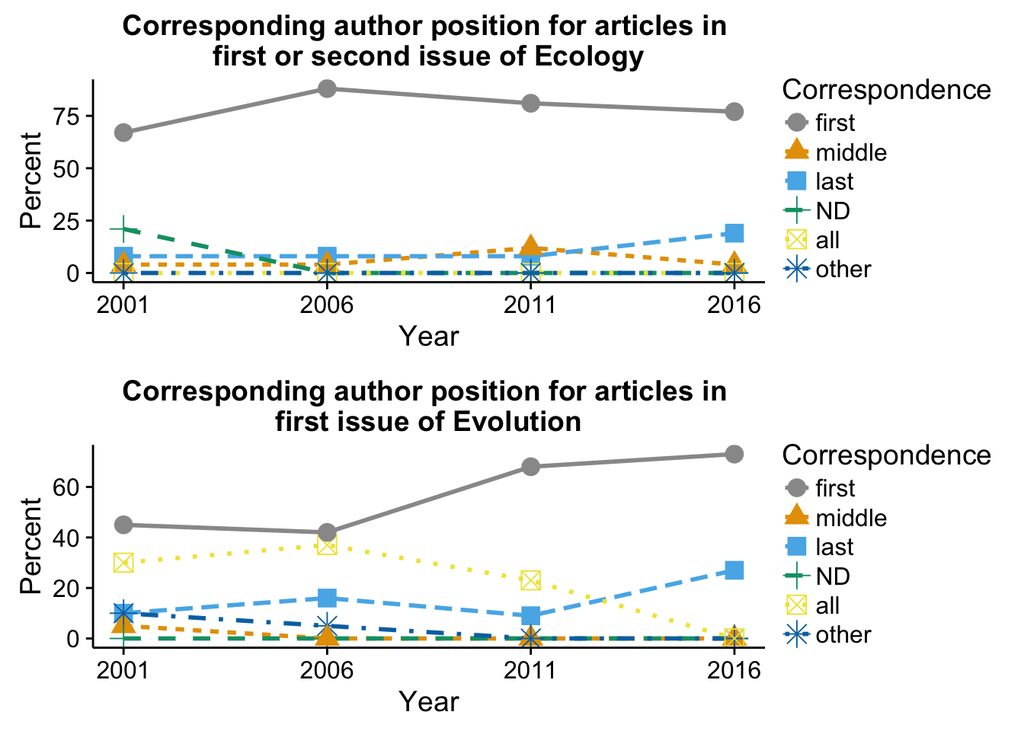